# Progress report 3

### Boxplots grouped by processing variable

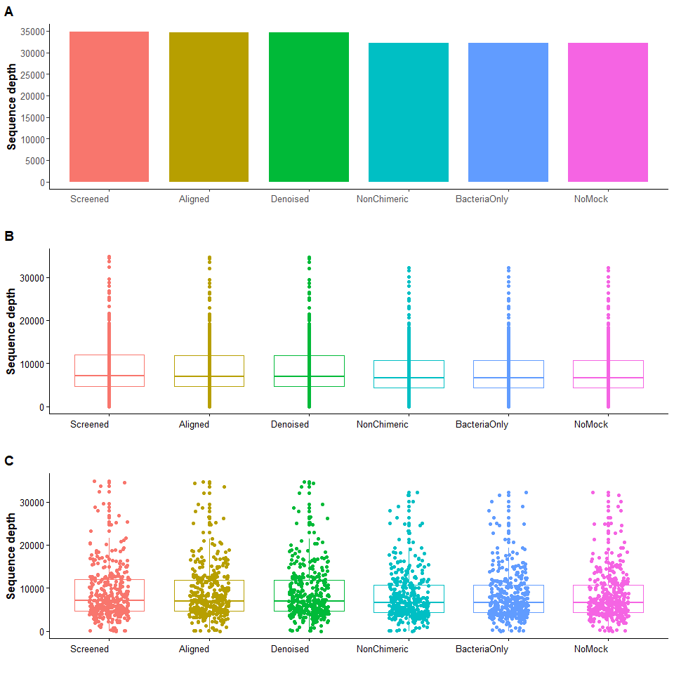

### Boxplots grouped by sex and time variable

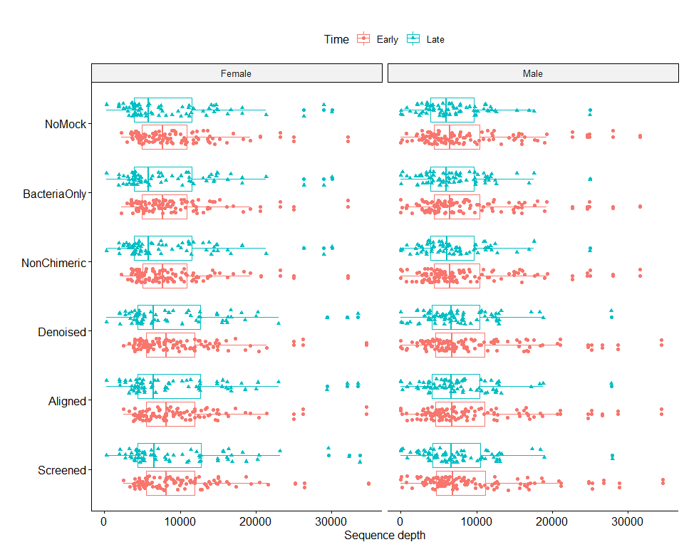

### Publication-ready distribution plots

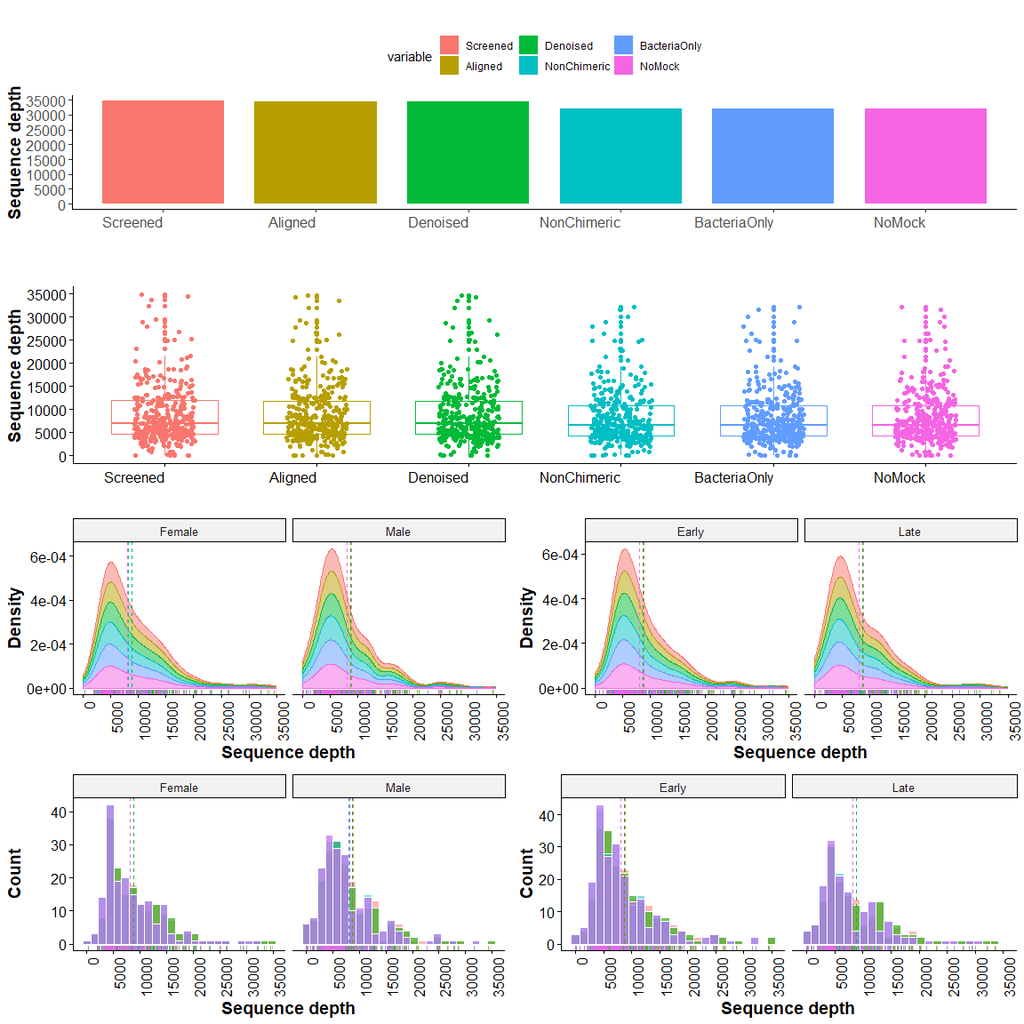

# Posible questions

### At sequence processing

- QN1: Do the paired sequences overlap as expected?
- QN2: Are there sequences to be removed from the analysis based on sequence length?
- QN3: Does the dorminant length match the targeted region of 16S rRNA gene?
- QN4: Are the representative sequences too few or too many? Note that too many non-redundant sequences may results from poor overlapping between forward and reverse reads. Review before proceeding to avoid misleading conclusions.